# European COVID-19 Forecast Hub Evaluation Report for epiforecasts-EpiExpert_direct

2021-11-08

# Latest forecasts

No recent forecasts to show. Click the `Forecast` tab above to view all past forecasts.

## Predictive performance

Skill is shown as weighted interval score.

### Cases

#### 1 week ahead horizon

##### Overall predictive performance

The table shows the skill of the epiforecasts-EpiExpert_direct model relative to the baseline (`vs. baseline`) and the ensemble model (`vs. ensemble`) for the past 10 weeks in terms of the Weighted Interval Score (`WIS`) and Absolute Error (`AE`). Values less than 1 indicate the model performs better than the model it is being compared with, and values greater than 1 that it performs worse. WIS values are only shown if all 23 quantiles are provided.

| Location | WIS vs. baseline | WIS vs. ensemble | AE vs. baseline | AE vs. ensemble |
| --- | --- | --- | --- | --- |
| Germany | 1.02 | 1.4 | 0.79 | 1.1 |
| Netherlands | 0.91 | 2.22 | 0.44 | 1.16 |
| United Kingdom | 1.59 | 1.64 | 1 | 0.87 |

##### Performance over time

The plots below show the data and forecasts with 50% and 90% predictive intervals and, in the panel to the right of the data plots, forecast skill as measured by the Weighted Interval Score. Lower values indicate better predictive performance.

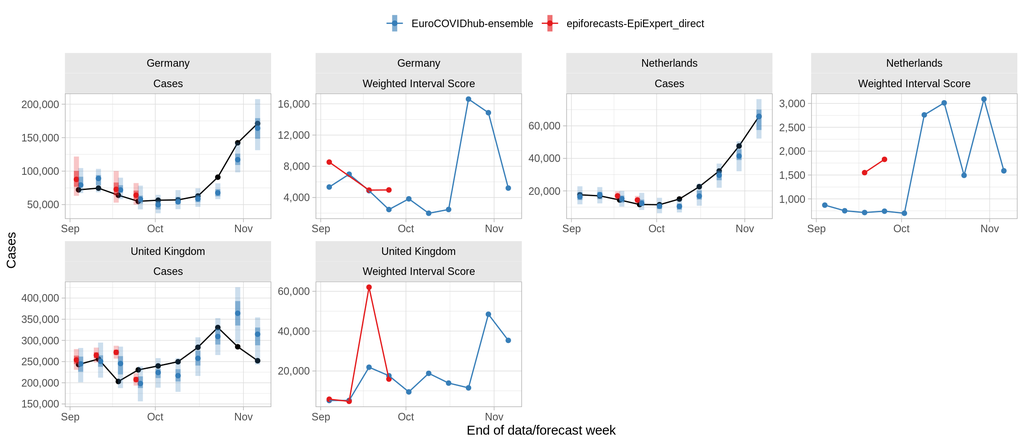

#### 2 weeks ahead horizon

##### Overall predictive performance

The table shows the skill of the epiforecasts-EpiExpert_direct model relative to the baseline (`vs. baseline`) and the ensemble model (`vs. ensemble`) for the past 10 weeks in terms of the Weighted Interval Score (`WIS`) and Absolute Error (`AE`). Values less than 1 indicate the model performs better than the model it is being compared with, and values greater than 1 that it performs worse. WIS values are only shown if all 23 quantiles are provided.

| Location | WIS vs. baseline | WIS vs. ensemble | AE vs. baseline | AE vs. ensemble |
| --- | --- | --- | --- | --- |
| Germany | 1.55 | 1.57 | 1.09 | 1.1 |
| Netherlands | 0.81 | 1.37 | 0.34 | 0.54 |
| United Kingdom | 1.72 | 1.47 | 1.12 | 0.84 |

##### Performance over time

The plots below show the data and forecasts with 50% and 90% predictive intervals and, in the panel to the right of the data plots, forecast skill as measured by the Weighted Interval Score. Lower values indicate better predictive performance.

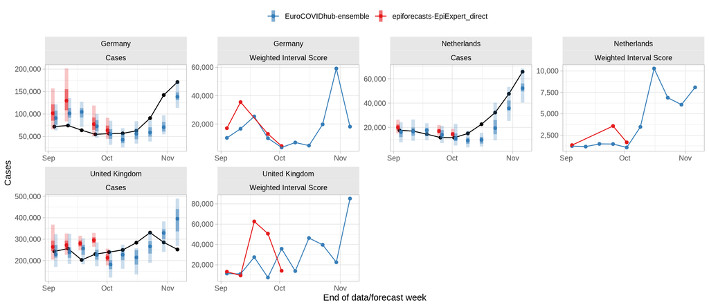

#### 3 weeks ahead horizon

##### Overall predictive performance

The table shows the skill of the epiforecasts-EpiExpert_direct model relative to the baseline (`vs. baseline`) and the ensemble model (`vs. ensemble`) for the past 10 weeks in terms of the Weighted Interval Score (`WIS`) and Absolute Error (`AE`). Values less than 1 indicate the model performs better than the model it is being compared with, and values greater than 1 that it performs worse. WIS values are only shown if all 23 quantiles are provided.

| Location | WIS vs. baseline | WIS vs. ensemble | AE vs. baseline | AE vs. ensemble |
| --- | --- | --- | --- | --- |
| Germany | 2.17 | 1.79 | 1.5 | 1.21 |
| Ireland | 1.52 | 1.41 | 1.8 | 1.61 |
| Netherlands | 0.62 | 0.77 | 0.25 | 0.28 |
| Poland | 0.65 | 1.55 | 0.04 | 0.07 |
| United Kingdom | 1.76 | 1.34 | 1.4 | 1.09 |

##### Performance over time

The plots below show the data and forecasts with 50% and 90% predictive intervals and, in the panel to the right of the data plots, forecast skill as measured by the Weighted Interval Score. Lower values indicate better predictive performance.

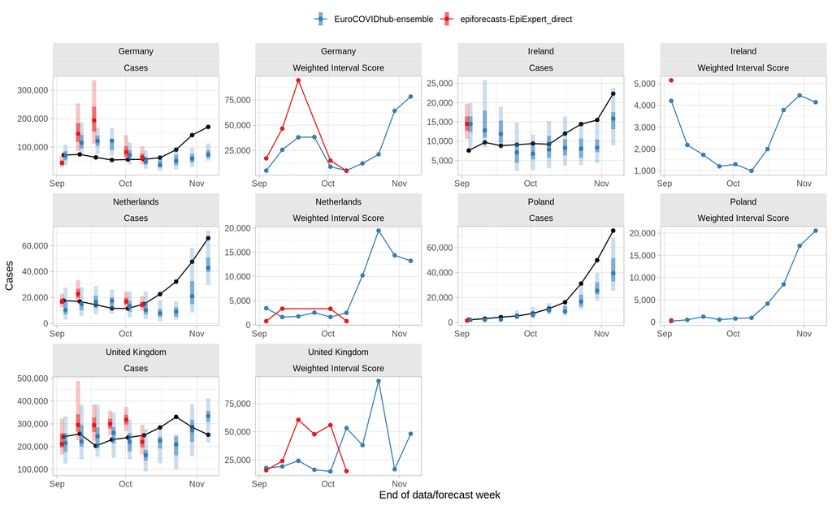

#### 4 weeks ahead horizon

##### Overall predictive performance

The table shows the skill of the epiforecasts-EpiExpert_direct model relative to the baseline (`vs. baseline`) and the ensemble model (`vs. ensemble`) for the past 10 weeks in terms of the Weighted Interval Score (`WIS`) and Absolute Error (`AE`). Values less than 1 indicate the model performs better than the model it is being compared with, and values greater than 1 that it performs worse. WIS values are only shown if all 23 quantiles are provided.

| Location | WIS vs. baseline | WIS vs. ensemble | AE vs. baseline | AE vs. ensemble |
| --- | --- | --- | --- | --- |
| Germany | 2.76 | 1.83 | 1.98 | 1.29 |
| Ireland | 3.01 | 2.3 | 2.03 | 1.66 |
| Netherlands | 0.96 | 0.97 | 0.45 | 0.39 |
| Poland | 0.73 | 1.49 | 0.05 | 0.08 |
| United Kingdom | 1.9 | 1.25 | 1.86 | 1.27 |

##### Performance over time

The plots below show the data and forecasts with 50% and 90% predictive intervals and, in the panel to the right of the data plots, forecast skill as measured by the Weighted Interval Score. Lower values indicate better predictive performance.

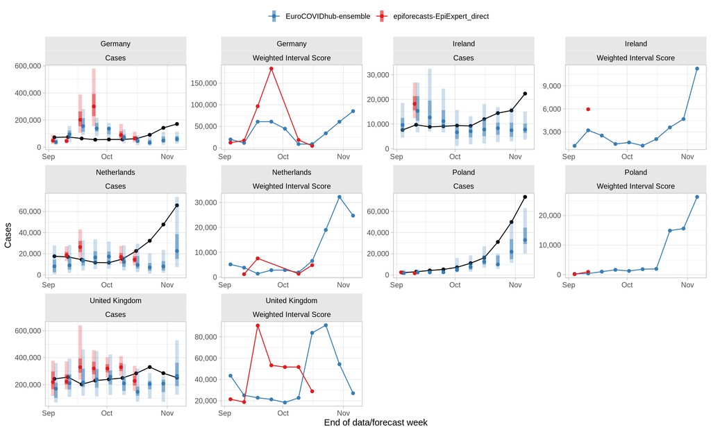

### Deaths

#### 1 week ahead horizon

##### Overall predictive performance

The table shows the skill of the epiforecasts-EpiExpert_direct model relative to the baseline (`vs. baseline`) and the ensemble model (`vs. ensemble`) for the past 10 weeks in terms of the Weighted Interval Score (`WIS`) and Absolute Error (`AE`). Values less than 1 indicate the model performs better than the model it is being compared with, and values greater than 1 that it performs worse. WIS values are only shown if all 23 quantiles are provided.

| Location | WIS vs. baseline | WIS vs. ensemble | AE vs. baseline | AE vs. ensemble |
| --- | --- | --- | --- | --- |
| Germany | 0.39 | 0.81 | 0.47 | 0.84 |
| Netherlands | 1.82 | 2.72 | 0.68 | 0.85 |
| United Kingdom | 1.01 | 1.6 | 1.43 | 1.7 |

##### Performance over time

The plots below show the data and forecasts with 50% and 90% predictive intervals and, in the panel to the right of the data plots, forecast skill as measured by the Weighted Interval Score. Lower values indicate better predictive performance.

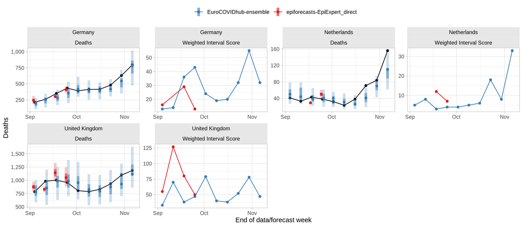

#### 2 weeks ahead horizon

##### Overall predictive performance

The table shows the skill of the epiforecasts-EpiExpert_direct model relative to the baseline (`vs. baseline`) and the ensemble model (`vs. ensemble`) for the past 10 weeks in terms of the Weighted Interval Score (`WIS`) and Absolute Error (`AE`). Values less than 1 indicate the model performs better than the model it is being compared with, and values greater than 1 that it performs worse. WIS values are only shown if all 23 quantiles are provided.

| Location | WIS vs. baseline | WIS vs. ensemble | AE vs. baseline | AE vs. ensemble |
| --- | --- | --- | --- | --- |
| Germany | 0.59 | 1.28 | 0.61 | 0.92 |
| Netherlands | 1.06 | 1.63 |  |  |
| United Kingdom | 0.59 | 1.18 | 0.94 | 1.29 |

##### Performance over time

The plots below show the data and forecasts with 50% and 90% predictive intervals and, in the panel to the right of the data plots, forecast skill as measured by the Weighted Interval Score. Lower values indicate better predictive performance.

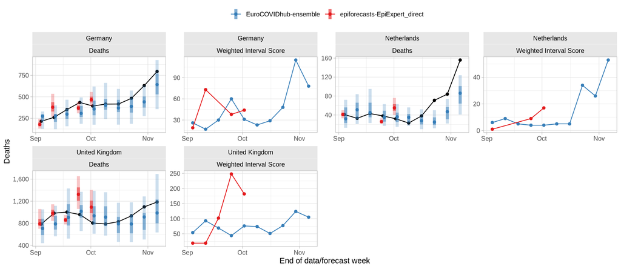

#### 3 weeks ahead horizon

##### Overall predictive performance

The table shows the skill of the epiforecasts-EpiExpert_direct model relative to the baseline (`vs. baseline`) and the ensemble model (`vs. ensemble`) for the past 10 weeks in terms of the Weighted Interval Score (`WIS`) and Absolute Error (`AE`). Values less than 1 indicate the model performs better than the model it is being compared with, and values greater than 1 that it performs worse. WIS values are only shown if all 23 quantiles are provided.

| Location | WIS vs. baseline | WIS vs. ensemble | AE vs. baseline | AE vs. ensemble |
| --- | --- | --- | --- | --- |
| Germany | 0.69 | 1.23 | 0.6 | 0.82 |
| Ireland | 0.35 | 0.51 | 0.2 | 0.18 |
| Netherlands | 1.04 | 1.68 | 0.52 | 0.5 |
| Poland | 0.3 | 1.11 | 0.08 | 0.22 |
| United Kingdom | 0.79 | 1.41 | 1.17 | 1.36 |

##### Performance over time

The plots below show the data and forecasts with 50% and 90% predictive intervals and, in the panel to the right of the data plots, forecast skill as measured by the Weighted Interval Score. Lower values indicate better predictive performance.

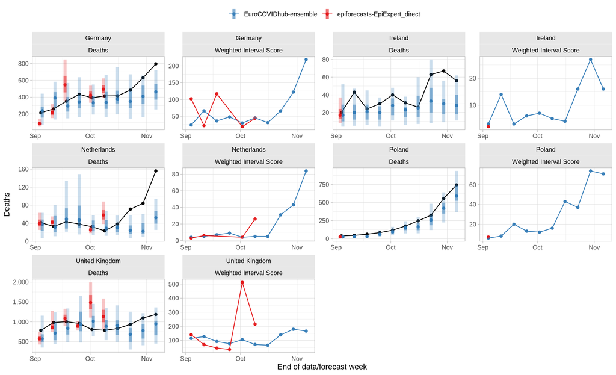

#### 4 weeks ahead horizon

##### Overall predictive performance

The table shows the skill of the epiforecasts-EpiExpert_direct model relative to the baseline (`vs. baseline`) and the ensemble model (`vs. ensemble`) for the past 10 weeks in terms of the Weighted Interval Score (`WIS`) and Absolute Error (`AE`). Values less than 1 indicate the model performs better than the model it is being compared with, and values greater than 1 that it performs worse. WIS values are only shown if all 23 quantiles are provided.

| Location | WIS vs. baseline | WIS vs. ensemble | AE vs. baseline | AE vs. ensemble |
| --- | --- | --- | --- | --- |
| Germany | 0.88 | 1.38 | 0.8 | 1.04 |
| Ireland | 0.88 | 1.16 | 1.24 | 1.29 |
| Netherlands | 0.44 | 0.63 | 0.37 | 0.29 |
| Poland | 0.6 | 1.88 | 0.13 | 0.3 |
| United Kingdom | 0.87 | 1.45 | 1.41 | 1.24 |

##### Performance over time

The plots below show the data and forecasts with 50% and 90% predictive intervals and, in the panel to the right of the data plots, forecast skill as measured by the Weighted Interval Score. Lower values indicate better predictive performance.

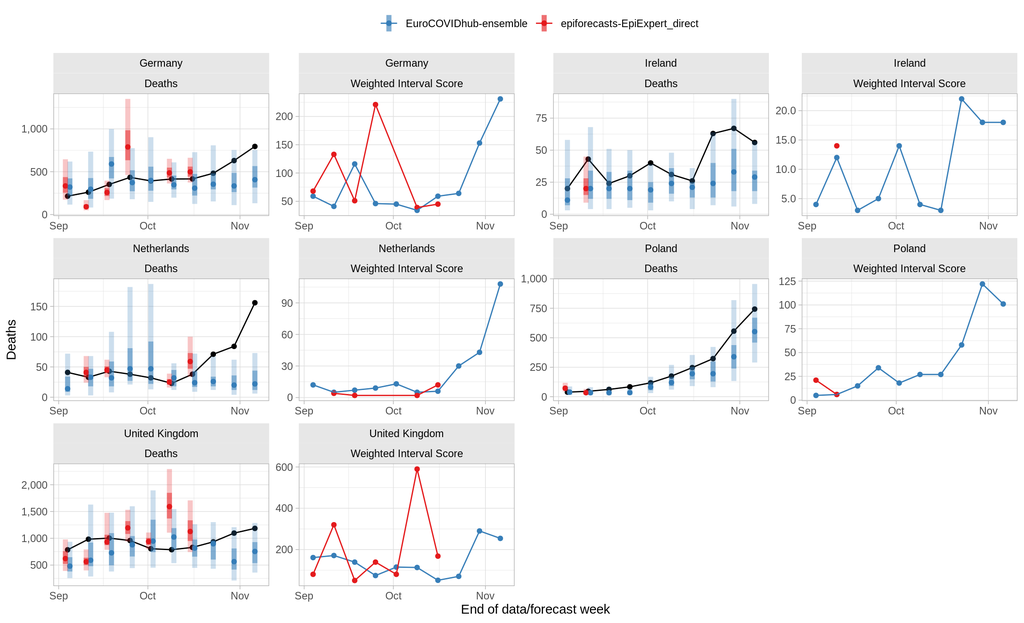

# Forecast calibration

The plots below describe the *calibration* of the model, that is its ability to correctly quantify its uncertainty, across all predicted countries.

#### Overall coverage

Coverage is the proportion of observations that fall within a given prediction interval. Ideally, a forecast model would achieve 50% coverage of 0.50 (i.e., 50% of observations fall within the 50% prediction interval) and 95% coverage of 0.95 (i.e., 95% of observations fall within the 95% prediction interval), incidcated by the dashed horizontal lines below. Values of coverage greater than these nominal values indicate that the forecasts are *underconfident*, i.e. prediction intervals tend to be too wide, whereas values of coverage smaller than these nominal values indicate that the ensemble forecasts are *overconfident*, i.e. prediction intervals tend to be too narrow.

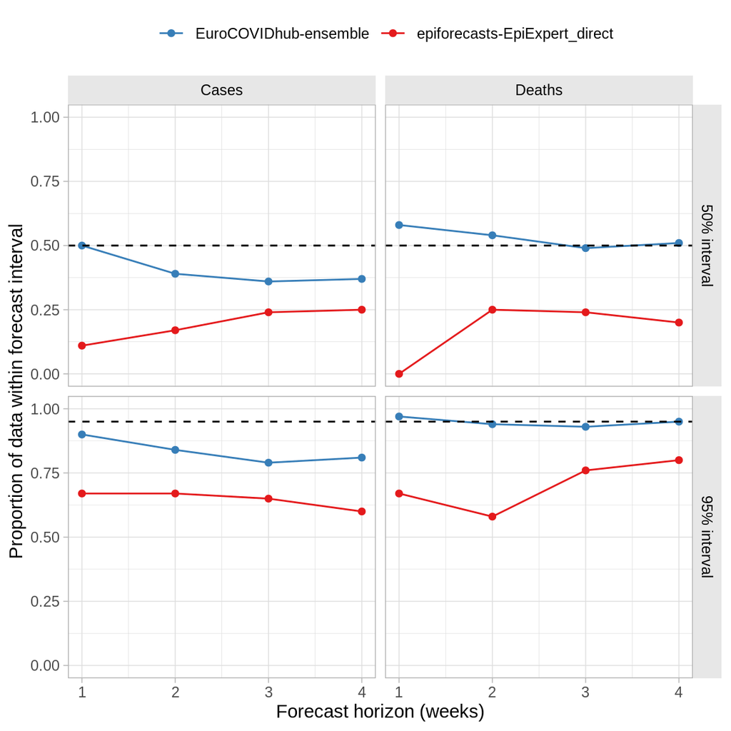

#### PIT histograms

The figures below are *PIT histograms* for the all past forecasts. These show the proportion of true values within each predictive quantile (width: 0.1). If the forecasts were perfectly calibrated, observations would fall evenly across these equally-spaced quantiles, i.e. the histograms would be flat.

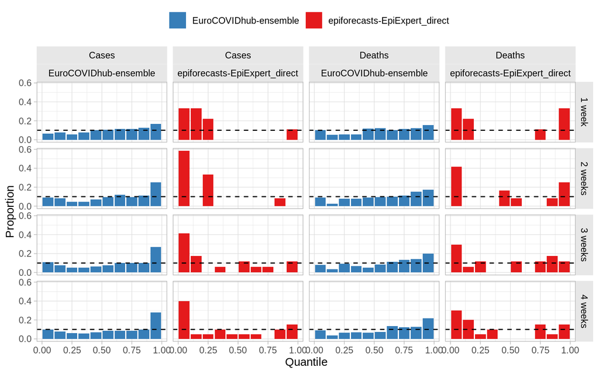